# Data Visualisation using RShiny

**Tanzania**, August, 2019

## Introduction to leaflet

### **What is leaflet?**

- "Leaflet is a widely used open source JavaScript library used to build web mapping applications."

### **Why leaflet?**

- Great way to explore datasets with geographic component
- Communicate your results with interactive maps
- Combine with shiny to produce even more interactive maps

## Course Overview

### **Day 1:**

- Getting to know your data
- Data subsetting, summarising
- Building exploratory plots
- Building an interactive plot in RShiny

### **Day 2:**

- Introduction to leaflet
- Building a leaflet map in R
- Building an interactive map in RShiny

### **Day 3:**

- Review
- Build your own apps!

## Getting Help

## Deadly virus spreads through Tanzania!

**Your mission** Visualise the disease advance and save the wildlife and citizens of Tanzania!!

## Day 2

- **1.1 Introduction to leaflet**
- 1.2 Building a leaflet map in R
- 1.3 Building an interactive map in RShiny

## Day 2

- **1.1 Introduction to leaflet**
- 1.2 Building an interactive leaflet map in R
- 1.3 Building an *even more* interactive map in RShiny

## Getting to know the data

Step 1: Set the working directory

```r
# Set your working directory by clicking on the top menu:
# Session > Set Working Directory > To Source File Location
```

Step 2: Load packages

```r
library("dplyr")
```

Step 3: Read in the data

```r
raw_data <- read.csv("../../Day 1/data/raw_data.csv")
```

## Getting to know the data

We have several tools to get to know our data

- `View()`: allows us to view the dataframe as a spreadsheet.
- `nrow()`: tells us the number of rows in our data frame.
- `names()`: give us the names of the columns in our data frame.
- `dim()`: tells us the dimensions of our dataframes.
- `summary()`: give us summary statistics (counts, min, median, mean, max).
- `head()`: gives us the first 6 elements of the data.
- `tail()`: gives us the last 6 elements of the data.
- `str()`: tells us the variable type (e.g. Factor, num (number), int (integer)).
- `unique()`: tells us the unique elements of a variable.
- `table()`: gives us count number for the columns specified.
- `?` and `??` accesses the help file for a function.

## Your Turn

- Navigate to Day 1/worksheets, and open **1.0_worksheet.html**
- All the activities we'll guide you to are in this file.
- The contents table is interactive - you can click to move to the activity.

Complete section 1.1a of the worksheet

## Map Basics

```r
# create variable for type of species
raw_data$species_type[which(raw_data$species=="dog" | raw_data$species=="cat")] <- "Domestic"
raw_data$species_type[which(raw_data$species %in% c("jackal", "lion"))] <- "Wildlife"
raw_data$species_type[which(raw_data$species=="human")] <- "Human"

# Use only one year
leaflet_data <- raw_data %>%
  dplyr::mutate(year = substr(date, 1,4)) %>%
  dplyr::filter(year == 2014)
```

## Getting started with our map

**We'll create a leaflet object `m` and add features, one step at a time.**

To start, we can create a default widget using `leaflet()`:

```r
m <- leaflet()
```

Next, add circles for our data points using `addCircles()`:

```r
m <- m %>%
  addCircles(data=leaflet_data, lng=~x, lat=~y)

m <- addCircles(m, data=leaflet_data, lng=~x, lat=~y)
m <- addCircles(m, data=leaflet_data, lng=~x, lat=~y)
```

## Using tiles to put data in geographic context

```r
# use the pipe operator to feed m into addTiles():
m %>% addTiles()
```

[interactive chart not shown]

## Alternative tiles using `addProviderTiles()`

**Allows us to use third party tiles (e.g. Terrain tiles from Stamen Design).**

```r
# m created using code from previous slides
m <- leaflet() %>%
  addCircles(data=leaflet_data, lng=~x, lat=~y)
```

**Code options**

```r
addProviderTiles(map = m, provider = "Stamen.Terrain")

addProviderTiles(map = m, provider = providers$Stamen.Terrain)

m %>% addProviderTiles(provider = providers$Stamen.Terrain)
```

## Alternative tiles using `addProviderTiles()`

```r
m %>% addProviderTiles(providers$Stamen.Terrain)
```

[interactive chart not shown]

## Your turn

Try out a couple of the options for provider tiles.

Hint: Use tab completion with the cursor placed after the `$` in `addProviderTiles(providers$)`

## Alternative tiles using `addProviderTiles()`

```r
m %>% addProviderTiles(providers$Esri.NatGeoWorldMap)
```

[interactive chart not shown]

## Alternative tiles using `addProviderTiles()`

```r
m %>% addProviderTiles(providers$Wikimedia)
```

[interactive chart not shown]

## Alternative tiles using `addProviderTiles()`

```r
m %>% addProviderTiles(providers$Esri.WorldTopoMap)
```

[interactive chart not shown]

## Alternative tiles using `addProviderTiles()`

```r
m %>% addProviderTiles(providers$Esri.WorldImagery)
```

[interactive chart not shown]

## Alternative tiles using `addProviderTiles()`

```r
m <- m %>% addProviderTiles(providers$CartoDB.Positron)
m
```

[interactive chart not shown]

## More info on `addProviderTiles()`

https://github.com/leaflet-extras/leaflet-providers  
**Full list of free-to-use tiles with previews:**  
http://leaflet-extras.github.io/leaflet-providers/preview/index.html  
**Tile servers based on OpenStreetMap data with info on how to cite:**  
https://wiki.openstreetmap.org/wiki/Tile_servers

e.g. When using the tiles provider$CartoDB.Positron:  
*Figure 1. Map of Tanzanian dataset. Cases coloured blue. Map tiles by Carto, under CC BY 3.0. Data by OpenStreetMap, under ODbL.*

## Editing data icons

```r
?addCircles
```

## Popups

Interactive way for user to explore dataset

```r
# We can create an object which has everything we want to display
popupInfo <- paste("Date: ", leaflet_data$date, "<br>",
                   "Species: ", leaflet_data$species, "<br>",
                   "Age: ", leaflet_data$age, "<br>",
                   sep = " ")
```

Then, refer to `popupInfo` when using `addCircles()`, `addCircleMarkers()` etc.

```r
m <- leaflet() %>%
  addProviderTiles(providers$CartoDB.Positron) %>%
  addCircleMarkers(data=leaflet_data, lng=~x, lat=~y, popup = popupInfo)
```

## Popups

**An interactive way for the user to explore a dataset**

Easier to first store what we want to display as an object `popupInfo`

```r
popupInfo <- paste("Date: ", leaflet_data$date, "<br>",
                   "Species: ", leaflet_data$species, "<br>",
                   "Age: ", leaflet_data$age, "<br>",
                   sep = " ")
```

Then, refer to `popupInfo` when using `addCircles()`, `addCircleMarkers()` etc.

```r
m <- leaflet() %>%
  addProviderTiles(providers$CartoDB.Positron) %>%
  addCircleMarkers(data=leaflet_data, lng=~x, lat=~y, popup = popupInfo)
```

## Popups

**An interactive way for the user to explore a dataset**

```r
m
```

[interactive chart not shown]

## Introducing colour palettes in leaflet

**Using the `colorFactor()` and `colorNumeric()` functions**

## Discrete variable - colour by species type

Create a fresh version of `m`:

```r
m <- leaflet() %>%
  addProviderTiles(providers$CartoDB.Positron)
```

`leaflet::colourFactor()` creates a function (we're going to call it `myPal`) that is used as an argument when we use `addCircles()`

```r
# Choose 3 colours for our 3 groups
colour_pal <- c("gold", "forestgreen", "cornflowerblue")
myPal <- colorFactor(colour_pal,
                     domain = c("Human", "Domestic", "Wildlife"))
```

## Discrete variable - colour by species type

```r
# myPal() takes species type variable as argument
m <- m %>% addCircles(data=leaflet_data, lng=~x, lat=~y,
                      color = myPal(leaflet_data$species_type), opacity = 0.9)
m
```

[interactive chart not shown]

## Adding a legend

```r
m <-  m %>% addLegend(position = "topright", title = "Species<br>type", pal = myPal,
                      values = leaflet_data$species_type, opacity = 0.5)
m
```

[interactive chart not shown]

## Your turn

Adapt below code to produce a map with:  
1) tiles showing elevation  
2) circles coloured by species (instead of species type)  
3) a legend for colour  
4) a scale bar showing distance in kilometers (hint: ?addScaleBar).

```r
colour_pal <- c("gold", "forestgreen", "cornflowerblue")
myPal <- colorFactor(colour_pal, domain = c("Human", "Domestic", "Wildlife"))
m <- leaflet() %>%
  addProviderTiles(providers$CartoDB.Positron) %>%
  addCircles(data=leaflet_data, lng=~x, lat=~y,
             color = myPal(leaflet_data$species_type), opacity = 0.9) %>%
  addLegend(position = "topright", title = "Species<br>type", pal = myPal,
            values = leaflet_data$species_type, opacity = 0.5)
m
```

## Solution

Part 1) tiles showing elevation

```r
m <- leaflet() %>%
  addProviderTiles(providers$OpenTopoMap)
m
```

[interactive chart not shown]

## Solution

Part 2) circles coloured by species (instead of species type)

```r
colour_pal <- c("gold", "forestgreen", "cornflowerblue", "red", "magenta")
myPal <- colorFactor(colour_pal, domain = unique(leaflet_data$species))
m <- m %>% addCircles(data = leaflet_data, lng = ~x, lat = ~y,
                      color = myPal(leaflet_data$species), opacity = 0.9)
```

## Solution

Part 3) a legend for colour

```r
m <- m %>% addLegend(position = "topright", title = "Species", pal = myPal,
                     values = leaflet_data$species, opacity = 0.5)
```

## Solution

Part 4) a scale bar showing distance in kilometers

```r
m <- m %>% addScaleBar(position = "bottomleft",
                       options = scaleBarOptions(maxWidth = 200, # default = 100
                                                 imperial = FALSE))
m
```

[interactive chart not shown]

## Solution

[interactive chart not shown]

## Continuous variable - colour by date

First, need to convert date variable to a numeric value

```r
head(leaflet_data$date, 5)
```

```
## [1] "2014-01-01" "2014-01-01" "2014-01-02" "2014-01-03" "2014-01-04"
```

```r
is.character(leaflet_data$date)
```

```
## [1] TRUE
```

```r
# Use 2 functions from lubridate for conversion
leaflet_data$date_decimal <- lubridate::decimal_date(lubridate::ymd(leaflet_data$date))
```

## Continuous variable - colour by date

First, need to convert date variable to a numeric value

```r
# Use 2 functions from lubridate for conversion
leaflet_data$date_decimal <- lubridate::decimal_date(lubridate::ymd(leaflet_data$date))

head(leaflet_data$date_decimal)
```

```
## [1] 2014.000 2014.000 2014.003 2014.005 2014.008 2014.014
```

```r
is.numeric(leaflet_data$date_decimal)
```

```
## [1] TRUE
```

## Continuous variable - colour by date

```r
dateRange <- c(2014, 2015)
myPal <- leaflet::colorNumeric(col_palette, dateRange)
m <- leaflet() %>%
  addProviderTiles(providers$CartoDB.Positron) %>%
  addCircles(data=leaflet_data, lng=~x, lat=~y,
             color = myPal(leaflet_data$date_decimal), opacity = 0.9) %>%
  addLegend(position = "topright", title = "Date",
                pal = myPal, values = dateRange,
                labFormat = labelFormat(big.mark = ""))  %>% # remove comma from 2,014)
  addScaleBar(position = "bottomleft",
              options = scaleBarOptions(maxWidth = 200))
```

## Continuous variable - colour by date

```r
m
```

[interactive chart not shown]

## Using leaflet and shape file data in raster format

## Using leaflet and environmental data in raster format

## Loading raster data

Load data using raster() from the raster package

```r
density <- raster::raster("../../Day 1/data/HumanPopulation.grd")
density
```

```
## class       : RasterLayer
## dimensions  : 259, 267, 69153  (nrow, ncol, ncell)
## resolution  : 0.041665, 0.041665  (x, y)
## extent      : 29.32649, 40.45105, -11.77259, -0.9813543  (xmin, xmax, ymin, ymax)
## coord. ref. : +proj=longlat +datum=WGS84 +no_defs +ellps=WGS84 +towgs84=0,0,0
## data source : /Users/wharvey/Documents/git/ShinyCourse/Day 1/data/HumanPopulation.grd
## names       : TZA_popmap10adj_v2b
## values      : 0, 29089.56  (min, max)
```

## Loading raster data

Load data using raster() from the raster package

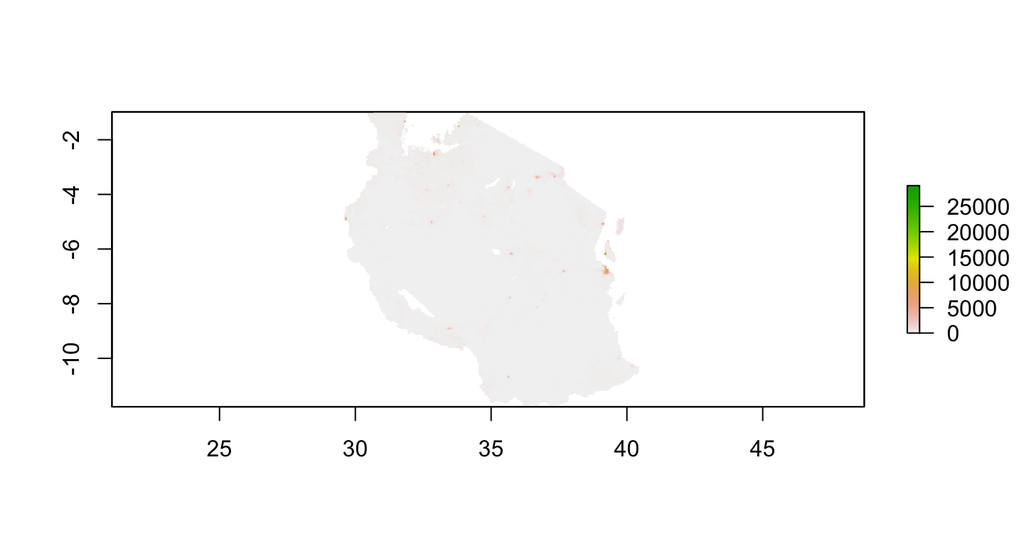

```r
density <- raster::raster("../../Day 1/data/HumanPopulation.grd")
plot(density)
```

## Loading raster data

Load data using raster() from the raster package

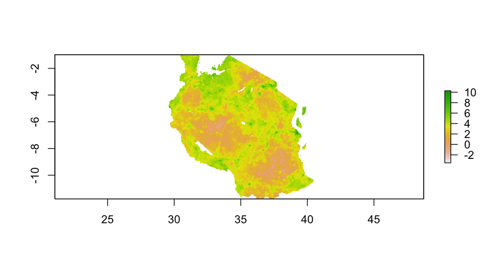

```r
density <- raster::raster("../../Day 1/data/HumanPopulation.grd")
plot(log(density))
```

## Plotting raster data with leaflet

We use `colorNumeric()` again, as we did to colour by date earlier

```r
colour_pal <- c("#FFFFCC", "#41B6C4", "#0C2C84")
raster::values(density) %>% range(na.rm = T)
```

```
## [1]     0.00 29089.56
```

```r
myPal <- colorNumeric(palette = colour_pal, domain = c(0, 30000), na.color = "red")

m <- leaflet() %>%
  addRasterImage(x = density, colors = myPal, opacity = 0.8)
```

## Plotting raster data with leaflet

[interactive chart not shown]

## Plotting raster data with leaflet

Let's log density as we did before

```r
raster::values(density) %>% range(na.rm = T) %>% log
```

```
## [1]     -Inf 10.27813
```

```r
myPal <- colorNumeric(palette = colour_pal, domain = c(-1.5, 11),
                      na.color = "transparent")
```

We have to exclude some data, as there are 0 density polygons and log(0) gives -infinity

```r
sum(raster::values(density) > exp(-1.5), na.rm = T) /
  sum(raster::values(density) >= 0, na.rm = T)
```

```
## [1] 0.9975207
```

## Plotting raster data with leaflet

Plot the logged raster data with some tiles and a legend for the colour scheme.

```r
m <- leaflet() %>%
  addProviderTiles(provider = providers$CartoDB.Positron) %>%
  addRasterImage(x = log(density), colors = myPal, opacity = 0.8) %>%
  addLegend(pal = myPal, values = c(-1.5, 11), opacity = 0.8,
            title = "Human<br>population<br>density")
```

## Plotting raster data with leaflet

[interactive chart not shown]

## Plotting raster data with leaflet

We order things here so that the raster data is on top of the background tiles (`providers$CartoDB.PositronNoLabels`), and then plot only the labels (`providers$CartoDB.PositronOnlyLabels`) on top of the raster data.

```r
m <- leaflet() %>%
  addProviderTiles(provider = providers$CartoDB.PositronNoLabels) %>%
  addRasterImage(x = log(density), colors = myPal, opacity = 0.8) %>%
  addProviderTiles(provider = providers$CartoDB.PositronOnlyLabels) %>%
  addLegend(pal = myPal, values = c(-1.5, 11), opacity = 0.8,
            title = "Human<br>population<br>density")
```

## Plotting raster data with leaflet

[interactive chart not shown]